# Zaawansowane modele liniowe 1

Błażej Wiórek

3/17/2020

## Zbiór danych

Zbiór składa się z dwóch zmiennych objaśniających:

1. Numeracy - wynik testów rachunkowych
2. Anxiety - poziom niepewności

Przed przejściem do właściwego zadania (dopasowania modelu) warto sprawdzić rozkład wartości w poszczególnych predyktorach oraz stosunek klas w zmiennej objaśnianej.

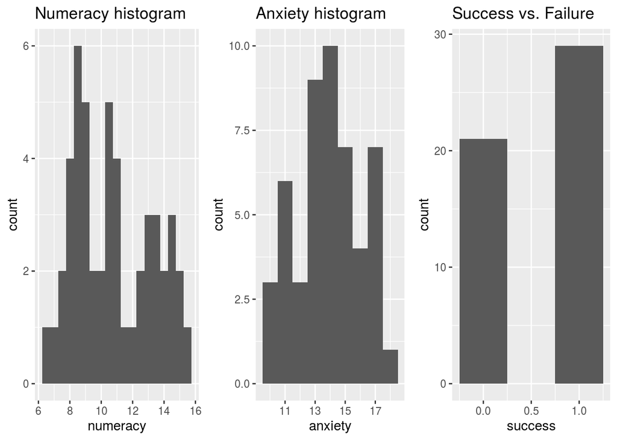

Wnioski: Na podstawie histogramów można stwierdzić, że w zbiorze nie występują wartości odstające oraz liczba skucesów i porażek jest porównywalna. Można więc przejść do dopasowania modelu bez dalszego wkładu pracy.

## Dopasowanie modelu (logit)

Zadanie składa się z czterech podpunktów:

1. Przeanalizowanie zbioru danych za pomocą regresji logistycznej.
2. Podanie estymatorów parametrów i wyniki testów istotności.
3. Określenie jakie jest przewidywane p-stwo sukcesu u studenta, którego anxiety=13 a numeracy=10.
4. Wyrysowanie krzywej ROC dla dopasowanego modelu statystycznego.

Podsumowanie wygenerowane dla dopasowanego modelu umożliwia zrealizowanie podpunktów a) - b).

Wykorzystana funkcja łącząca (logit) ma następującą postać:
$$logit(p_i) = log(\frac{p_i}{1 - p_i})$$

Przy czym $p_i = P(Y=1|X_i)$.

```
##
## Call:
## glm(formula = success ~ numeracy + anxiety, family = binomial,
##     data = data_df)
##
## Deviance Residuals:
##      Min        1Q    Median        3Q       Max
## -1.83958  -0.30510   0.04823   0.35431   2.08545
##
## Coefficients:
##             Estimate Std. Error z value Pr(>|z|)
## (Intercept)  14.2386     6.7985   2.094  0.03623 *
## numeracy      0.5774     0.2481   2.327  0.01995 *
## anxiety      -1.3841     0.4804  -2.881  0.00396 **
## ---
## Signif. codes:  0 '***' 0.001 '**' 0.01 '*' 0.05 '.' 0.1 ' ' 1
##
## (Dispersion parameter for binomial family taken to be 1)
##
##     Null deviance: 68.029  on 49  degrees of freedom
## Residual deviance: 28.286  on 47  degrees of freedom
## AIC: 34.286
##
## Number of Fisher Scoring iterations: 6
```

Dopasowany model regresji logistycznej ma następującą postać:
$$\eta(p_i) = 14.2386 + 0.5774 * numeracy_i - 1.3841 * anxiety_i$$

Przedstawione wartości statystyki testowej oznaczone jako ‘z value’ i związane z nimi p-wartości ‘Pr(>|z|)’ odzwierciedlają wyniki testu Walda. Test Walda ma następującą postać: $H_0: \beta_i = 0$, $H_A: \beta_i \neq 0$. Wykorzystana statystyka: $W = \frac{\beta_i}{var(\beta_i)}$. Pod warunkiem $H_0$, rozkład statystyki można przybliżyć za pomocą standardowego rozkładu normalnego.

Obliczenie prawdopodobieństwo sukcesu dla studenta u którego anxiety=13 i numeracy=10 można przeprowadzić ręcznie na podstawie wzoru:
$$p = \frac{e^{\hat{\beta_0} + \hat{\beta_1}*10 + \hat{\beta_2}*13}}{1 + e^{\hat{\beta_0} + \hat{\beta_1}*10 + \hat{\beta_2}*13}}$$

[output not shown]

Można również skorzystać z gotowej funkcji:

[output not shown]

## Dopasowanie modelu (probit)

Wykorzystana funkcja łącząca (probit) ma następującą postać:
$$probit(p_i) = \Phi^{-1}(p_i)$$

```
##
## Call:
## glm(formula = success ~ numeracy + anxiety, family = binomial(link = "probit"),
##     data = data_df)
##
## Deviance Residuals:
##      Min        1Q    Median        3Q       Max
## -1.81586  -0.28203   0.00909   0.33527   2.07312
##
## Coefficients:
##             Estimate Std. Error z value Pr(>|z|)
## (Intercept)   8.2573     3.6753   2.247  0.02466 *
## numeracy      0.3371     0.1368   2.464  0.01374 *
## anxiety      -0.8039     0.2519  -3.191  0.00142 **
## ---
## Signif. codes:  0 '***' 0.001 '**' 0.01 '*' 0.05 '.' 0.1 ' ' 1
##
## (Dispersion parameter for binomial family taken to be 1)
##
##     Null deviance: 68.029  on 49  degrees of freedom
## Residual deviance: 27.854  on 47  degrees of freedom
## AIC: 33.854
##
## Number of Fisher Scoring iterations: 8
```

Dopasowany model regresji logistycznej ma następującą postać:
$$\eta(p_i) = 8.2573 + 0.3371 * numeracy_i - 0.8039 * anxiety_i$$

```
## [1] "Automatically estimated probability for numeracy=13, anxiety=10:  0.8806"
```

Podstawowym scenariuszem dla funkcji probit jest sytuacja w której istnieje podejrzenie, że wektor odpowiedzi powstał wskutek obcięcia regresji liniowej. Rrzeczywiście jeśli przyjąć, że $\widetilde{y} = -x^T\beta + \epsilon$, przy czym $\epsilon \sim N(0, 1)$ oraz
$$y =
\begin{cases}
1 & \mbox{jeśli } \widetilde{y} \leq 0\\
0 & \mbox{jeśli } \widetilde{y} > 0
\end{cases}$$

wtedy: $\mathbb{P}(y=1|x) = \mathbb{P}(\widetilde{y} \leq 0 ) = \mathbb{P}(-x^T\beta + \epsilon \leq 0) = \mathbb{P}(\epsilon \leq x^T \beta) = \Phi(x^T \beta)$ z czego wynika, że: $x^T \beta = \Phi(\mathbb{P}(y=1|x))$.

## Dopasowanie modelu (cauchit)

Wykorzystana funkcja łącząca (cauchit) ma następującą postać:
$$cauchit(p_i) = F^{-1}(p_i)$$
Przy czym F to dystrybuanta rozkładu Cauchy’ego.

```
##
## Call:
## glm(formula = success ~ numeracy + anxiety, family = binomial(link = "cauchit"),
##     data = data_df)
##
## Deviance Residuals:
##     Min       1Q   Median       3Q      Max
## -1.9482  -0.4108   0.2727   0.4289   2.0650
##
## Coefficients:
##             Estimate Std. Error z value Pr(>|z|)
## (Intercept)  18.3830    12.2994   1.495   0.1350
## numeracy      0.7323     0.4741   1.545   0.1224
## anxiety      -1.7741     0.9914  -1.789   0.0735 .
## ---
## Signif. codes:  0 '***' 0.001 '**' 0.01 '*' 0.05 '.' 0.1 ' ' 1
##
## (Dispersion parameter for binomial family taken to be 1)
##
##     Null deviance: 68.029  on 49  degrees of freedom
## Residual deviance: 31.115  on 47  degrees of freedom
## AIC: 37.115
##
## Number of Fisher Scoring iterations: 10
```

Warto zauważyć, że zgodnie z przedstawionym podsumowaniem, wyniki testów istotności poszczególnych predyktorów nie dają podstaw do odrzucenia $H_0: \beta_0 = 0$ i $H_0: \beta_1 = 0$. Wydaje się, że istnieje zależność pomiędzy zmienną ‘anxiety’ a zmienną objaśnianą, jednak p-wartość dla ‘anxiety’ również jest relatywnie wysoka.

Dopasowany model regresji logistycznej ma następującą postać:
$$\eta(p_i) = 18.3830 + 0.7323 * numeracy_i - 1.7741 * anxiety_i$$

```
## [1] "Automatically estimated probability for numeracy=13, anxiety=10:  0.88485"
```

## Dopasowanie modelu (cloglog)

Wykorzystana funkcja łącząca (cloglog) ma następującą postać:
$$cloglog(p_i) = log(-log(1 - p_i))$$

```
##
## Call:
## glm(formula = success ~ numeracy + anxiety, family = binomial(link = "cloglog"),
##     data = data_df)
##
## Deviance Residuals:
##     Min       1Q   Median       3Q      Max
## -1.7764  -0.3824   0.0000   0.2088   2.0203
##
## Coefficients:
##             Estimate Std. Error z value Pr(>|z|)
## (Intercept)   9.0006     4.6524   1.935  0.05304 .
## numeracy      0.4024     0.1522   2.644  0.00819 **
## anxiety      -0.9390     0.3322  -2.827  0.00470 **
## ---
## Signif. codes:  0 '***' 0.001 '**' 0.01 '*' 0.05 '.' 0.1 ' ' 1
##
## (Dispersion parameter for binomial family taken to be 1)
##
##     Null deviance: 68.029  on 49  degrees of freedom
## Residual deviance: 28.000  on 47  degrees of freedom
## AIC: 34
##
## Number of Fisher Scoring iterations: 9
```

Dopasowany model regresji logistycznej ma następującą postać:
$$\eta(p_i) = 9.0006 + 0.4024 * numeracy_i - 0.9390 * anxiety_i$$

```
## [1] "Automatically estimated probability for numeracy=13, anxiety=10:  0.89631"
```

Przeprowadzając rozumowanie analogiczne do tego, które rozpisane zostało dla funkcji probit okazuje się, że funkcje cloglog stosuje się gdy istnieje podejrzenie, że wektor odpowiedzi powstał wskutek obcięcia zmiennej losowej o rozkładzie Poissona tzn: $\widetilde{y} = Poi(\lambda)$ przy czym:
$$y =
\begin{cases}
1 & \mbox{jeśli } \widetilde{y} \geq 1\\
0 & \mbox{jeśli } \widetilde{y} = 0
\end{cases}$$

## Porównanie przedstawionych modeli

```
##              AIC Deviance
## logit   34.28562 28.28562
## probit  33.85445 27.85445
## cauchit 37.11479 31.11479
## cloglog 33.99973 27.99973
```

Model wykorzystujący probit jako link function charakteryzuje się najniższą wartością AIC oraz Deviance. Na tej podstawie można stwierdzić, że jest to model o najlepszym dopasowaniu tzn. najmniejszym błędzie.

Ogólnie warto zauważyć, że wszystkie wartości są do siebie zbliżone, z czego wynika, że przedstawione modele niewiele się od siebie różnią. Różnice pomiędzy poszczególnymi funkcjami przedstawione zostały na wykresie poniżej:

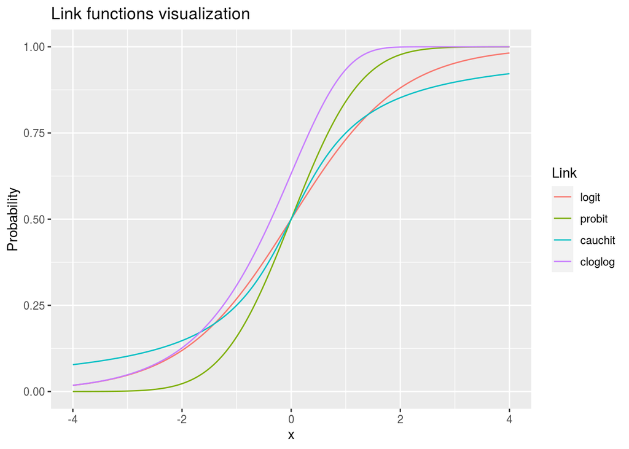

### Krzywe ROC

Innym sposobem na porównanie skuteczności modeli jest wykorzystanie krzywej ROC. Aby zrozumieć sens stosowania krzywych ROC należy najpierw zastanowić się w jaki sposób regresja logistyczna wykonuje zadanie klasyfikacji binarnej. Jako, że model umożliwia estymowanie prawdopodobieństwa $p_i = P(Y=1|X_i)$, wykorzystuje się następującą regułę: $Y=1$ jeśli $p_i \geq T$ oraz $Y=0$ w przeciwnym wypadku. Wartość $T \in [0,1]$ to tzw. threshold.

Zwiększanie wartości $T$ powoduje, że coraz trudniej jest przypisać obserwację do $Y=1$. Analogicznie jeśli wartość $T$ będzie obniżana, coraz więcej obserwacji będzie przypisywanych do $Y=1$.

Zastanówmy się teraz nad dwiema miarami oceny skuteczności klasyfikatora binarnego:
$$TruePositiveRate = \frac{TP}{FN + TP}$$

$$FalsePositiveRate = \frac{FP}{TN + FP}$$

Jeśli $T=0$, wtedy dla każdej obserwacji przypisywane jest $Y=1$, łatwo zaobserwować, że w takiej sytuacji $FPR = TPR = 1$

Jeśli $T=1$, wtedy dla każdej obserwacji przypisywane jest $Y=0$, łatwo zaobserwować, że w takiej sytuacji $FPR = TPR = 0$

Przechodząc z wartościami $T$ od 0 do 1 i obliczając dla kolejnych wartości $TPR$ i $FPR$, otrzymam punkty składające się na krzywą ROC. Pole pod wykresem krzywej ROC nazywane jest AUC (area under the curve) i wykorzystywane jest do oceny skuteczności modeli.

[figure not shown]